# Cars4U Pricing Linear Model

## Summary

Cars4U is tech start-up that is attempting to gain a foothold in the Indian used car market. The Indian used car market has recnetly grown as the demand for new cars has diminished. **Generally speaking, new cars have more stable (less variable) prices across regions and dealerships than used cars.** This is due in part, to the fact that new car prices are largely determined by the origninal equipment manufacturer (OEM).

As a result, Cars4U needs to be able to assess the price of used cars within the market. **Develop a model which could enable Cars4U to better estimate the actual price of a used car to help them devise effective pricing strategies.**

## Objectives

- Explore & visualize the dataset.
- Build a linear regression model to predict the prices of used cars.
- Generate a set of insights and recommendations that will help Cars4U.

  ## Data Dictionary
1. S.No.: Serial Number
2. Name: Name of the car; includes brand and model
3. Location: The location (cities) in which the car is being sold or is available
4. Year: Manufacturing year of the car
5. Kilometers_driven: Mileage in kilometers on teh vehicle
6. Fuel_Type: Type of fuel used by the car (Petrol, Diesel, Electric, CNG, LPG)
7. Transmission: Type of transmission (Automatic/Manual)
8. Owner: Type of ownership
9. Mileage: Standard mileage offered by the car company (kmpl or km/kg)
10. Engine: Displacement volume of the engine in CC
11. Power: The maximum power of the engine in bhp
12. Seats: Number of seats in the car
13. New_Price: Price of a new car of the same model in INR Lakhs (1 Lakh = 100,000)
14. Price: Price of used car in INR Lakhs (1 Lakh = 100,000)

```python
"""Import all packages needed for the script"""
import numpy as np
import pandas as pd
import matplotlib.pyplot as plt
import seaborn as sns
import re

import pylab
import scipy.stats as stats
import statsmodels.api as sm

from sklearn.model_selection import train_test_split
from sklearn.linear_model import LinearRegression
from sklearn.metrics import mean_squared_error
from sklearn.preprocessing import StandardScaler, MinMaxScaler

pd.set_option("display.max_columns", None)
pd.set_option("display.max_rows", 200)

sns.set_style("darkgrid")

%matplotlib inline
import warnings
warnings.filterwarnings('ignore')
```

## Data Exploration and Cleaning

```python
"""Import the data and safe as a raw dataframe for cleaning and preprocessing"""
data = pd.read_csv("used_cars_data.csv")
raw_df = data.copy()
```

```python
"""Examine sample of the data to begin to assess what might need to be done"""
raw_df.sample(100)
```

|  | S.No. | Name | Location | Year | Kilometers_Driven | Fuel_Type | Transmission | Owner_Type | Mileage | Engine | Power | Seats | New_Price | Price |
| --- | --- | --- | --- | --- | --- | --- | --- | --- | --- | --- | --- | --- | --- | --- |
| 2587 | 2587 | Nissan Terrano XL 85 PS | Bangalore | 2014 | 87000 | Diesel | Manual | First | 20.45 kmpl | 1461 CC | 83.8 bhp | 5.0 | NaN | 6.50 |
| 1122 | 1122 | Honda City i VTEC CVT VX | Kochi | 2016 | 58197 | Petrol | Automatic | First | 18.0 kmpl | 1497 CC | 117.3 bhp | 5.0 | NaN | 9.19 |
| 6634 | 6634 | Volkswagen Polo 1.5 TDI Highline | Jaipur | 2015 | 62766 | Diesel | Manual | First | 20.14 kmpl | 1498 CC | 88.8 bhp | 5.0 | NaN | NaN |
| 3031 | 3031 | Maruti Ertiga VXI CNG | Mumbai | 2013 | 53000 | CNG | Manual | First | 22.8 km/kg | 1373 CC | 80.9 bhp | 7.0 | NaN | 5.80 |
| 6957 | 6957 | Honda Jazz 2020 Petrol | Kochi | 2019 | 11574 | Petrol | Manual | First | 0.0 kmpl | 1199 CC | 88.7 bhp | NaN | NaN | NaN |
| 4937 | 4937 | Honda Jazz 1.5 V i DTEC | Pune | 2015 | 97000 | Diesel | Manual | First | 27.3 kmpl | 1498 CC | 98.6 bhp | 5.0 | NaN | 6.40 |
| 5511 | 5511 | Ford Figo Diesel Titanium | Hyderabad | 2014 | 74624 | Diesel | Manual | First | 20.0 kmpl | 1399 CC | 68.05 bhp | 5.0 | NaN | 5.65 |
| 1580 | 1580 | Hyundai i10 Magna 1.2 | Mumbai | 2008 | 62000 | Petrol | Manual | Second | 20.36 kmpl | 1197 CC | 78.9 bhp | 5.0 | NaN | 1.65 |
| 932 | 932 | Mercedes-Benz New C-Class C 200 Avantgarde Edi... | Kochi | 2011 | 71703 | Petrol | Automatic | First | 14.74 kmpl | 1991 CC | 181.03 bhp | 5.0 | NaN | 9.14 |
| 2936 | 2936 | Toyota Etios Liva G | Chennai | 2015 | 53713 | Petrol | Manual | First | 17.71 kmpl | 1197 CC | 78.9 bhp | 5.0 | NaN | 4.20 |
| 5748 | 5748 | Maruti Ciaz VDi Plus SHVS | Hyderabad | 2015 | 67048 | Diesel | Manual | First | 28.09 kmpl | 1248 CC | 88.5 bhp | 5.0 | NaN | 7.90 |
| 1875 | 1875 | Toyota Innova 2.5 LE 2014 Diesel 7 Seater | Pune | 2014 | 102418 | Diesel | Manual | First | 12.99 kmpl | 2494 CC | 100.6 bhp | 7.0 | NaN | 10.10 |
| 14 | 14 | Land Rover Freelander 2 TD4 SE | Pune | 2012 | 85000 | Diesel | Automatic | Second | 0.0 kmpl | 2179 CC | 115 bhp | 5.0 | NaN | 17.50 |
| 5718 | 5718 | Ford Figo Diesel Titanium | Hyderabad | 2012 | 73500 | Diesel | Manual | Second | 20.0 kmpl | 1399 CC | 68 bhp | 5.0 | NaN | 2.60 |
| 3039 | 3039 | Mercedes-Benz E-Class 2009-2013 E250 CDI Blue ... | Hyderabad | 2010 | 93000 | Diesel | Automatic | Second | 14.21 kmpl | 2143 CC | 203 bhp | 5.0 | NaN | 17.50 |
| 4475 | 4475 | Hyundai Verna 1.6 SX VTVT (O) | Delhi | 2013 | 52000 | Petrol | Manual | First | 17.1 kmpl | 1591 CC | 121.3 bhp | 5.0 | NaN | 5.25 |
| 5198 | 5198 | Maruti Ertiga VDI | Pune | 2014 | 71899 | Diesel | Manual | First | 20.77 kmpl | 1248 CC | 88.76 bhp | 7.0 | NaN | 7.25 |
| 4538 | 4538 | Skoda Yeti Elegance | Hyderabad | 2010 | 110009 | Diesel | Manual | First | 17.67 kmpl | 1968 CC | 138.08 bhp | 5.0 | NaN | 6.99 |
| 6988 | 6988 | Nissan Terrano XE 85 PS | Jaipur | 2013 | 54000 | Diesel | Manual | First | 20.45 kmpl | 1461 CC | 83.8 bhp | 5.0 | NaN | NaN |
| 5404 | 5404 | BMW 5 Series 2003-2012 520d | Pune | 2010 | 170000 | Diesel | Automatic | Third | 18.48 kmpl | 1995 CC | 177 bhp | 5.0 | NaN | 12.00 |
| 3433 | 3433 | Mitsubishi Pajero 2.8 GLX CRZ | Mumbai | 2004 | 129000 | Diesel | Manual | First | 10.5 kmpl | 2835 CC | 107.2 bhp | 6.0 | NaN | 3.45 |
| 6178 | 6178 | Ford EcoSport 1.5 Diesel Titanium | Chennai | 2015 | 67630 | Diesel | Manual | First | 23.0 kmpl | 1498 CC | 98.96 bhp | 5.0 | 11.48 Lakh | NaN |
| 4903 | 4903 | Hyundai EON Sportz | Coimbatore | 2014 | 14799 | Petrol | Manual | First | 21.1 kmpl | 814 CC | 55.2 bhp | 5.0 | NaN | 4.14 |
| 5185 | 5185 | Maruti Swift 1.3 LXI | Delhi | 2012 | 52000 | Petrol | Manual | First | 16.1 kmpl | NaN | NaN | NaN | NaN | 3.65 |
| 39 | 39 | Volkswagen Polo Diesel Trendline 1.2L | Chennai | 2013 | 62000 | Diesel | Manual | First | 22.07 kmpl | 1199 CC | 73.9 bhp | 5.0 | NaN | 5.00 |
| 246 | 246 | Honda City i VTEC V | Kochi | 2016 | 33915 | Petrol | Manual | First | 17.8 kmpl | 1497 CC | 117.3 bhp | 5.0 | NaN | 8.09 |
| 955 | 955 | Hyundai i20 1.2 Asta | Delhi | 2013 | 71000 | Petrol | Manual | First | 17.0 kmpl | 1197 CC | 80 bhp | 5.0 | NaN | 3.65 |
| 4955 | 4955 | Maruti Swift VXI BSIV | Bangalore | 2006 | 80010 | Petrol | Manual | Second | 20.4 kmpl | 1197 CC | 81.80 bhp | 5.0 | NaN | 2.85 |
| 1830 | 1830 | Mercedes-Benz GLE 350d | Coimbatore | 2017 | 33552 | Diesel | Automatic | First | 11.57 kmpl | 2987 CC | 254.79 bhp | 5.0 | 95.13 Lakh | 64.87 |
| 633 | 633 | Audi Q3 35 TDI Quattro Premium | Hyderabad | 2015 | 61000 | Diesel | Automatic | First | 15.73 kmpl | 1968 CC | 174.33 bhp | 5.0 | NaN | 25.00 |

[output cut: 70 more lines]

```python
print(raw_df.isna().sum())
raw_df.info()
```

```
S.No.                   0
Name                    0
Location                0
Year                    0
Kilometers_Driven       0
Fuel_Type               0
Transmission            0
Owner_Type              0
Mileage                 2
Engine                 46
Power                  46
Seats                  53
New_Price            6247
Price                1234
dtype: int64
<class 'pandas.core.frame.DataFrame'>
RangeIndex: 7253 entries, 0 to 7252
Data columns (total 14 columns):
 #   Column             Non-Null Count  Dtype
---  ------             --------------  -----
 0   S.No.              7253 non-null   int64
 1   Name               7253 non-null   object
 2   Location           7253 non-null   object
 3   Year               7253 non-null   int64
 4   Kilometers_Driven  7253 non-null   int64
 5   Fuel_Type          7253 non-null   object
 6   Transmission       7253 non-null   object
 7   Owner_Type         7253 non-null   object
 8   Mileage            7251 non-null   object
 9   Engine             7207 non-null   object
 10  Power              7207 non-null   object
 11  Seats              7200 non-null   float64
 12  New_Price          1006 non-null   object
 13  Price              6019 non-null   float64
dtypes: float64(2), int64(3), object(9)
memory usage: 793.4+ KB
```

#### Notes

- S. No. is not actually a serial number. It's just a count that matches the index exactly. **Need to drop.**
- **On Name, this column will need to be split into Make and Model.** Make may be a relavant parameter in the model as could certain models, but models will likely be unique identifiers. Will need to see once split.
- **Location, Fuel_Type, Transmission, and Owner_Type are all categorical variables** with what appear to be clean strings.
- **Year** is a clean integer. It can be changed to datetime format, but as long as years are the only information we need integers will work the same as datetime format for year on any given analysis.
  - **Kilometers_Driven** has no commas. Is already an integer, should **work as is**.
- **Mileage, Engine, and Power** have **units at the end of the number (kmpl, CC, bhp) which will need to removed and the columns made a *float64* or *int64.*** Mileage and Power should be floats, while Engine can be an integer. Data dictionary notes that Mileage is reported in kmpl and km/kg, fortunately these are the same units since 1 liter of water is 1 kg. Therefore, no conversion is needed.
- **New Price** contains the currency units (Lakh), which will have to be removed. Lakh simply means 100,000, therefore, will need to place (10^5) in column name as reminder that values are that much greater.
- There are many missing values. **Mostly in *New_Price* and *Price***. However, there are also a numer in *Seats, Power, Engine, and Mileage*. *Power and Engine* have the same number of missing values, which makes sense as both are parameters of the engine of the vehicle. However, confirming that those missing values are from the same vehicles will need to be done.

```python
"""Data cleaning and organization"""
# Remove Serial Number column
clean_df = raw_df.drop(['S.No.'], axis = 1)

# Split Name into Make and Model
"""First word is always the Make, all other words are related to Model"""
df = clean_df['Name'].str.split(' ', 1, expand=True) # Split string into two differnt columns
clean_df['Make'] = df[0] # Create columns in dataframe of corresponding Make and Model information
clean_df['Model'] = df[1]

clean_df.drop('Name', axis=1, inplace=True) # Remove Name column from dataframe
del df # Delete temporary dataframe used

# Solve capitalization errors in categorical data
categorical = ['Location', 'Fuel_Type', 'Transmission', 'Owner_Type', 'Make']
for i in categorical:
    clean_df[i] = clean_df[i].str.title()
    clean_df[i] = clean_df[i].astype('category')

# Adjust columns with numerical data and units so unit is in column title and data is numerical
cols = ['Mileage', 'Engine', 'Power']
for i in cols:
    df = clean_df[i].str.split(' ', 1, expand=True) # Split string into two differnt columns
    value = df[0] # Pull values and place
    unit = df[1].mode() # Pull unit string
    new_name = i + "({})".format(str(unit[0])) # Format new column name to retain unit information

    # Replace orignal series with just values. Values are converted to numerical data
    clean_df[i] = pd.to_numeric(df[0], errors='coerce') # Only non-numerical is "null" so replaced with NaN
    clean_df.rename(columns={i:new_name}, inplace=True) # Rename column with the units included in the name

# Change New_Price and Price column names to reflect that prices are the value show x10^5
clean_df['New_Price'] = pd.to_numeric(clean_df['New_Price'].str.split(' ', 1, expand=True)[0], errors='ignore')
clean_df.rename(columns={"New_Price":"New_Price(x10^5)",
                         "Price":"Price(x10^5)"
                        }, inplace=True)

clean_df['Model'] = clean_df['Model'].astype('category') # Turn Model into categorical data
clean_df.info()
```

```
<class 'pandas.core.frame.DataFrame'>
RangeIndex: 7253 entries, 0 to 7252
Data columns (total 14 columns):
 #   Column             Non-Null Count  Dtype
---  ------             --------------  -----
 0   Location           7253 non-null   category
 1   Year               7253 non-null   int64
 2   Kilometers_Driven  7253 non-null   int64
 3   Fuel_Type          7253 non-null   category
 4   Transmission       7253 non-null   category
 5   Owner_Type         7253 non-null   category
 6   Mileage(kmpl)      7251 non-null   float64
 7   Engine(CC)         7207 non-null   float64
 8   Power(bhp)         7078 non-null   float64
 9   Seats              7200 non-null   float64
 10  New_Price(x10^5)   1006 non-null   float64
 11  Price(x10^5)       6019 non-null   float64
 12  Make               7253 non-null   category
 13  Model              7253 non-null   category
dtypes: category(6), float64(6), int64(2)
memory usage: 585.7 KB
```

Data has been organized with strings removed from numerical data, columns with multiple points of data, and data has been assigned to the corresponding type.

```python
"""Explore and address all NaN values in the dataset"""
clean_df.isna().sum() # Check NaNs across columns
```

```
Location                0
Year                    0
Kilometers_Driven       0
Fuel_Type               0
Transmission            0
Owner_Type              0
Mileage(kmpl)           2
Engine(CC)             46
Power(bhp)            175
Seats                  53
New_Price(x10^5)     6247
Price(x10^5)         1234
Make                    0
Model                   0
dtype: int64
```

```python
clean_df[clean_df['Mileage(kmpl)'].isna()]
```

|  | Location | Year | Kilometers_Driven | Fuel_Type | Transmission | Owner_Type | Mileage(kmpl) | Engine(CC) | Power(bhp) | Seats | New_Price(x10^5) | Price(x10^5) | Make | Model |
| --- | --- | --- | --- | --- | --- | --- | --- | --- | --- | --- | --- | --- | --- | --- |
| 4446 | Chennai | 2016 | 50000 | Electric | Automatic | First | NaN | 72.0 | 41.0 | 5.0 | 13.58 | 13.00 | Mahindra | E Verito D4 |
| 4904 | Mumbai | 2011 | 44000 | Electric | Automatic | First | NaN | 1798.0 | 73.0 | 5.0 | NaN | 12.75 | Toyota | Prius 2009-2016 Z4 |

```python
clean_df[clean_df['Fuel_Type'] == 'Electric']
```

|  | Location | Year | Kilometers_Driven | Fuel_Type | Transmission | Owner_Type | Mileage(kmpl) | Engine(CC) | Power(bhp) | Seats | New_Price(x10^5) | Price(x10^5) | Make | Model |
| --- | --- | --- | --- | --- | --- | --- | --- | --- | --- | --- | --- | --- | --- | --- |
| 4446 | Chennai | 2016 | 50000 | Electric | Automatic | First | NaN | 72.0 | 41.0 | 5.0 | 13.58 | 13.00 | Mahindra | E Verito D4 |
| 4904 | Mumbai | 2011 | 44000 | Electric | Automatic | First | NaN | 1798.0 | 73.0 | 5.0 | NaN | 12.75 | Toyota | Prius 2009-2016 Z4 |

```python
clean_df[clean_df['Engine(CC)'].isna()]
```

|  | Location | Year | Kilometers_Driven | Fuel_Type | Transmission | Owner_Type | Mileage(kmpl) | Engine(CC) | Power(bhp) | Seats | New_Price(x10^5) | Price(x10^5) | Make | Model |
| --- | --- | --- | --- | --- | --- | --- | --- | --- | --- | --- | --- | --- | --- | --- |
| 194 | Ahmedabad | 2007 | 60006 | Petrol | Manual | First | 0.00 | NaN | NaN | NaN | NaN | 2.95 | Honda | City 1.5 GXI |
| 208 | Kolkata | 2010 | 42001 | Petrol | Manual | First | 16.10 | NaN | NaN | NaN | NaN | 2.11 | Maruti | Swift 1.3 VXi |
| 733 | Chennai | 2006 | 97800 | Petrol | Manual | Third | 16.10 | NaN | NaN | NaN | NaN | 1.75 | Maruti | Swift 1.3 VXi |
| 749 | Mumbai | 2008 | 55001 | Diesel | Automatic | Second | 0.00 | NaN | NaN | NaN | NaN | 26.50 | Land | Rover Range Rover 3.0 D |
| 1294 | Delhi | 2009 | 55005 | Petrol | Manual | First | 12.80 | NaN | NaN | NaN | NaN | 3.20 | Honda | City 1.3 DX |
| 1327 | Hyderabad | 2015 | 50295 | Petrol | Manual | First | 16.10 | NaN | NaN | NaN | NaN | 5.80 | Maruti | Swift 1.3 ZXI |
| 1385 | Pune | 2004 | 115000 | Petrol | Manual | Second | 0.00 | NaN | NaN | NaN | NaN | 1.50 | Honda | City 1.5 GXI |
| 1460 | Coimbatore | 2008 | 69078 | Petrol | Manual | First | 0.00 | NaN | NaN | NaN | NaN | 40.88 | Land | Rover Range Rover Sport 2005 2012 Sport |
| 2074 | Pune | 2011 | 24255 | Petrol | Manual | First | 16.10 | NaN | NaN | NaN | NaN | 3.15 | Maruti | Swift 1.3 LXI |
| 2096 | Coimbatore | 2004 | 52146 | Petrol | Manual | First | 0.00 | NaN | NaN | NaN | NaN | 1.93 | Hyundai | Santro LP zipPlus |
| 2264 | Pune | 2012 | 24500 | Petrol | Manual | Second | 18.30 | NaN | NaN | NaN | NaN | 2.95 | Toyota | Etios Liva V |
| 2325 | Pune | 2015 | 67000 | Petrol | Manual | First | 16.10 | NaN | NaN | NaN | NaN | 4.70 | Maruti | Swift 1.3 VXI ABS |
| 2335 | Mumbai | 2007 | 55000 | Petrol | Manual | Second | 16.10 | NaN | NaN | NaN | NaN | 1.75 | Maruti | Swift 1.3 VXi |
| 2530 | Kochi | 2014 | 64158 | Diesel | Automatic | First | 18.48 | NaN | NaN | NaN | NaN | 17.89 | Bmw | 5 Series 520d Sedan |
| 2542 | Bangalore | 2011 | 65000 | Petrol | Manual | Second | 0.00 | NaN | NaN | NaN | NaN | 3.15 | Hyundai | Santro GLS II - Euro II |
| 2623 | Pune | 2012 | 95000 | Diesel | Automatic | Second | 18.48 | NaN | NaN | NaN | NaN | 18.00 | Bmw | 5 Series 520d Sedan |
| 2668 | Kolkata | 2014 | 32986 | Petrol | Manual | First | 16.10 | NaN | NaN | NaN | NaN | 4.24 | Maruti | Swift 1.3 VXi |
| 2737 | Jaipur | 2001 | 200000 | Petrol | Manual | First | 12.00 | NaN | NaN | NaN | NaN | 0.70 | Maruti | Wagon R Vx |
| 2780 | Pune | 2009 | 100000 | Petrol | Manual | First | 0.00 | NaN | NaN | NaN | NaN | 1.60 | Hyundai | Santro GLS II - Euro II |
| 2842 | Bangalore | 2012 | 43000 | Petrol | Manual | First | 0.00 | NaN | NaN | NaN | NaN | 3.25 | Hyundai | Santro GLS II - Euro II |
| 3272 | Mumbai | 2008 | 81000 | Diesel | Automatic | Second | 18.48 | NaN | NaN | NaN | NaN | 10.50 | Bmw | 5 Series 520d Sedan |
| 3404 | Jaipur | 2006 | 125000 | Petrol | Manual | Fourth & Above | 16.10 | NaN | NaN | NaN | NaN | 2.35 | Maruti | Swift 1.3 VXi |
| 3520 | Delhi | 2012 | 90000 | Diesel | Automatic | First | 18.48 | NaN | NaN | NaN | NaN | 14.50 | Bmw | 5 Series 520d Sedan |
| 3522 | Kochi | 2012 | 66400 | Petrol | Manual | First | 0.00 | NaN | NaN | NaN | NaN | 2.66 | Hyundai | Santro GLS II - Euro II |
| 3810 | Kolkata | 2013 | 27000 | Petrol | Automatic | First | 14.00 | NaN | NaN | NaN | NaN | 11.99 | Honda | CR-V AT With Sun Roof |
| 4011 | Pune | 2011 | 45271 | Diesel | Manual | First | 20.30 | NaN | NaN | NaN | NaN | 2.60 | Fiat | Punto 1.3 Emotion |
| 4152 | Mumbai | 2003 | 75000 | Diesel | Automatic | Second | 0.00 | NaN | NaN | NaN | NaN | 16.11 | Land | Rover Range Rover 3.0 D |
| 4229 | Bangalore | 2005 | 79000 | Petrol | Manual | Second | 17.00 | NaN | NaN | NaN | NaN | 1.65 | Hyundai | Santro Xing XG |
| 4577 | Delhi | 2012 | 72000 | Diesel | Automatic | Third | 18.48 | NaN | NaN | NaN | NaN | 13.85 | Bmw | 5 Series 520d Sedan |
| 4604 | Pune | 2011 | 98000 | Petrol | Manual | First | 16.70 | NaN | NaN | NaN | NaN | 3.15 | Honda | Jazz Select Edition |
| 4697 | Kochi | 2017 | 17941 | Petrol | Manual | First | 15.70 | NaN | NaN | NaN | NaN | 3.93 | Fiat | Punto 1.2 Dynamic |
| 4712 | Pune | 2003 | 80000 | Petrol | Manual | Second | 17.00 | NaN | NaN | NaN | NaN | 0.90 | Hyundai | Santro Xing XG |
| 4952 | Kolkata | 2010 | 47000 | Petrol | Manual | First | 14.60 | NaN | NaN | NaN | NaN | 1.49 | Fiat | Punto 1.4 Emotion |
| 5015 | Delhi | 2006 | 63000 | Petrol | Manual | First | 16.10 | NaN | NaN | NaN | NaN | 1.60 | Maruti | Swift 1.3 VXi |
| 5185 | Delhi | 2012 | 52000 | Petrol | Manual | First | 16.10 | NaN | NaN | NaN | NaN | 3.65 | Maruti | Swift 1.3 LXI |
| 5270 | Bangalore | 2002 | 53000 | Petrol | Manual | Second | 0.00 | NaN | NaN | NaN | NaN | 1.85 | Honda | City 1.5 GXI |
| 6042 | Bangalore | 2009 | 72000 | Petrol | Manual | Second | 17.50 | NaN | NaN | NaN | NaN | NaN | Skoda | Laura 1.8 TSI Ambition |
| 6541 | Bangalore | 2012 | 56600 | Diesel | Manual | First | 23.59 | NaN | NaN | NaN | NaN | NaN | Toyota | Etios Liva Diesel TRD Sportivo |
| 6544 | Bangalore | 2012 | 58000 | Petrol | Automatic | Second | 15.00 | NaN | NaN | NaN | NaN | NaN | Hyundai | i20 new Sportz AT 1.4 |
| 6633 | Kolkata | 2016 | 27000 | Diesel | Manual | First | 0.00 | NaN | NaN | NaN | NaN | NaN | Mahindra | TUV 300 P4 |
| 6643 | Bangalore | 2009 | 150000 | Diesel | Automatic | Second | 18.48 | NaN | NaN | NaN | NaN | NaN | Bmw | 5 Series 520d Sedan |
| 6651 | Kolkata | 2015 | 36009 | Petrol | Manual | First | 16.10 | NaN | NaN | NaN | NaN | NaN | Maruti | Swift 1.3 VXi |
| 6677 | Jaipur | 2010 | 65000 | Petrol | Manual | Third | 14.60 | NaN | NaN | NaN | NaN | NaN | Fiat | Punto 1.4 Emotion |
| 6685 | Pune | 2010 | 115000 | Petrol | Manual | Second | 16.10 | NaN | NaN | NaN | NaN | NaN | Maruti | Swift 1.3 VXi |
| 6880 | Chennai | 2009 | 95000 | Diesel | Automatic | Second | 18.48 | NaN | NaN | NaN | NaN | NaN | Bmw | 5 Series 520d Sedan |
| 6902 | Kochi | 2012 | 59311 | Petrol | Manual | First | 18.30 | NaN | NaN | NaN | NaN | NaN | Toyota | Etios Liva V |

```python
clean_df[clean_df['Power(bhp)'].isna()]
```

|  | Location | Year | Kilometers_Driven | Fuel_Type | Transmission | Owner_Type | Mileage(kmpl) | Engine(CC) | Power(bhp) | Seats | New_Price(x10^5) | Price(x10^5) | Make | Model |
| --- | --- | --- | --- | --- | --- | --- | --- | --- | --- | --- | --- | --- | --- | --- |
| 76 | Jaipur | 2008 | 111111 | Diesel | Manual | First | 17.80 | 1399.0 | NaN | 5.0 | NaN | 2.00 | Ford | Fiesta 1.4 SXi TDCi |
| 79 | Hyderabad | 2005 | 87591 | Petrol | Manual | First | 0.00 | 1086.0 | NaN | 5.0 | NaN | 1.30 | Hyundai | Santro Xing XL |
| 89 | Hyderabad | 2007 | 73745 | Petrol | Manual | First | 17.00 | 1086.0 | NaN | 5.0 | NaN | 2.10 | Hyundai | Santro Xing XO |
| 120 | Mumbai | 2005 | 102000 | Petrol | Manual | Second | 17.00 | 1086.0 | NaN | 5.0 | NaN | 0.85 | Hyundai | Santro Xing XL eRLX Euro III |
| 143 | Kochi | 2008 | 80759 | Petrol | Manual | Third | 17.00 | 1086.0 | NaN | 5.0 | NaN | 1.67 | Hyundai | Santro Xing XO eRLX Euro II |
| 194 | Ahmedabad | 2007 | 60006 | Petrol | Manual | First | 0.00 | NaN | NaN | NaN | NaN | 2.95 | Honda | City 1.5 GXI |
| 208 | Kolkata | 2010 | 42001 | Petrol | Manual | First | 16.10 | NaN | NaN | NaN | NaN | 2.11 | Maruti | Swift 1.3 VXi |
| 227 | Delhi | 2013 | 47000 | Diesel | Manual | First | 17.80 | 1248.0 | NaN | 5.0 | NaN | 4.10 | Maruti | Swift VDI BSIV |
| 245 | Mumbai | 2007 | 72000 | Petrol | Manual | Third | 17.00 | 1086.0 | NaN | 5.0 | NaN | 0.95 | Hyundai | Santro Xing XO eRLX Euro II |
| 262 | Hyderabad | 2006 | 99000 | Petrol | Manual | First | 0.00 | 1086.0 | NaN | 5.0 | NaN | 1.75 | Hyundai | Santro Xing XL |
| 307 | Chennai | 2006 | 58000 | Petrol | Manual | Second | 0.00 | 1086.0 | NaN | 5.0 | NaN | 1.50 | Hyundai | Santro Xing XL |
| 308 | Kolkata | 2011 | 60020 | Diesel | Manual | First | 17.80 | 1248.0 | NaN | 5.0 | NaN | 2.50 | Maruti | Swift VDI BSIV |
| 386 | Hyderabad | 2007 | 50958 | Petrol | Manual | First | 17.00 | 1086.0 | NaN | 5.0 | NaN | 1.95 | Hyundai | Santro Xing XL eRLX Euro III |
| 424 | Hyderabad | 2010 | 42021 | Diesel | Manual | First | 0.00 | 1968.0 | NaN | 5.0 | NaN | 5.45 | Volkswagen | Jetta 2007-2011 1.9 L TDI |
| 428 | Pune | 2006 | 108000 | Petrol | Manual | Second | 17.00 | 1086.0 | NaN | 5.0 | NaN | 1.20 | Hyundai | Santro Xing XO eRLX Euro II |
| 443 | Coimbatore | 2012 | 50243 | Petrol | Manual | First | 0.00 | 1086.0 | NaN | 5.0 | NaN | 3.35 | Hyundai | Santro GLS I - Euro I |
| 472 | Chennai | 2009 | 80524 | Petrol | Manual | Second | 15.30 | 1596.0 | NaN | 5.0 | NaN | 2.50 | Ford | Fiesta 1.6 SXI ABS Duratec |
| 575 | Chennai | 2006 | 83072 | Petrol | Manual | First | 17.00 | 1086.0 | NaN | 5.0 | NaN | 1.40 | Hyundai | Santro Xing XO |
| 631 | Chennai | 2002 | 70000 | Petrol | Manual | Third | 0.00 | 1086.0 | NaN | 5.0 | NaN | 0.65 | Hyundai | Santro LS zipPlus |
| 647 | Jaipur | 2004 | 200000 | Petrol | Manual | First | 0.00 | 1086.0 | NaN | 5.0 | NaN | 0.80 | Hyundai | Santro Xing XP |
| 648 | Jaipur | 2009 | 82000 | Diesel | Manual | Second | 13.50 | 1405.0 | NaN | 5.0 | NaN | 0.75 | Tata | Indica DLS |
| 733 | Chennai | 2006 | 97800 | Petrol | Manual | Third | 16.10 | NaN | NaN | NaN | NaN | 1.75 | Maruti | Swift 1.3 VXi |
| 739 | Bangalore | 2007 | 60000 | Diesel | Manual | Second | 17.80 | 1248.0 | NaN | 5.0 | NaN | 3.40 | Maruti | Swift VDI BSIV |
| 748 | Hyderabad | 2007 | 71297 | Petrol | Manual | First | 17.00 | 1086.0 | NaN | 5.0 | NaN | 2.20 | Hyundai | Santro Xing XO |
| 749 | Mumbai | 2008 | 55001 | Diesel | Automatic | Second | 0.00 | NaN | NaN | NaN | NaN | 26.50 | Land | Rover Range Rover 3.0 D |
| 829 | Mumbai | 2012 | 29605 | Petrol | Manual | First | 18.30 | 1197.0 | NaN | 5.0 | NaN | 2.44 | Toyota | Etios Liva G |
| 915 | Pune | 2008 | 103000 | Diesel | Automatic | Second | 0.00 | 799.0 | NaN | 2.0 | NaN | 3.00 | Smart | Fortwo CDI AT |
| 926 | Hyderabad | 2010 | 10000 | Petrol | Manual | First | 9.00 | 3436.0 | NaN | 2.0 | NaN | 40.00 | Porsche | Cayman 2009-2012 S |
| 934 | Kolkata | 2012 | 60000 | Diesel | Manual | First | 23.59 | 1364.0 | NaN | 5.0 | NaN | 2.95 | Toyota | Etios GD |
| 1068 | Pune | 2012 | 225000 | Diesel | Manual | Second | 23.59 | 1364.0 | NaN | 5.0 | NaN | 2.60 | Toyota | Etios Liva GD |

[output cut: 145 more lines]

```python
clean_df[clean_df['Seats'].isna()]
```

|  | Location | Year | Kilometers_Driven | Fuel_Type | Transmission | Owner_Type | Mileage(kmpl) | Engine(CC) | Power(bhp) | Seats | New_Price(x10^5) | Price(x10^5) | Make | Model |
| --- | --- | --- | --- | --- | --- | --- | --- | --- | --- | --- | --- | --- | --- | --- |
| 194 | Ahmedabad | 2007 | 60006 | Petrol | Manual | First | 0.00 | NaN | NaN | NaN | NaN | 2.95 | Honda | City 1.5 GXI |
| 208 | Kolkata | 2010 | 42001 | Petrol | Manual | First | 16.10 | NaN | NaN | NaN | NaN | 2.11 | Maruti | Swift 1.3 VXi |
| 229 | Bangalore | 2015 | 70436 | Diesel | Manual | First | 0.00 | 1498.0 | 99.0 | NaN | NaN | 3.60 | Ford | Figo Diesel |
| 733 | Chennai | 2006 | 97800 | Petrol | Manual | Third | 16.10 | NaN | NaN | NaN | NaN | 1.75 | Maruti | Swift 1.3 VXi |
| 749 | Mumbai | 2008 | 55001 | Diesel | Automatic | Second | 0.00 | NaN | NaN | NaN | NaN | 26.50 | Land | Rover Range Rover 3.0 D |
| 1294 | Delhi | 2009 | 55005 | Petrol | Manual | First | 12.80 | NaN | NaN | NaN | NaN | 3.20 | Honda | City 1.3 DX |
| 1327 | Hyderabad | 2015 | 50295 | Petrol | Manual | First | 16.10 | NaN | NaN | NaN | NaN | 5.80 | Maruti | Swift 1.3 ZXI |
| 1385 | Pune | 2004 | 115000 | Petrol | Manual | Second | 0.00 | NaN | NaN | NaN | NaN | 1.50 | Honda | City 1.5 GXI |
| 1460 | Coimbatore | 2008 | 69078 | Petrol | Manual | First | 0.00 | NaN | NaN | NaN | NaN | 40.88 | Land | Rover Range Rover Sport 2005 2012 Sport |
| 1917 | Jaipur | 2005 | 88000 | Petrol | Manual | Second | 13.00 | 1493.0 | 100.0 | NaN | NaN | 1.70 | Honda | City 1.5 EXI |
| 2074 | Pune | 2011 | 24255 | Petrol | Manual | First | 16.10 | NaN | NaN | NaN | NaN | 3.15 | Maruti | Swift 1.3 LXI |
| 2096 | Coimbatore | 2004 | 52146 | Petrol | Manual | First | 0.00 | NaN | NaN | NaN | NaN | 1.93 | Hyundai | Santro LP zipPlus |
| 2264 | Pune | 2012 | 24500 | Petrol | Manual | Second | 18.30 | NaN | NaN | NaN | NaN | 2.95 | Toyota | Etios Liva V |
| 2325 | Pune | 2015 | 67000 | Petrol | Manual | First | 16.10 | NaN | NaN | NaN | NaN | 4.70 | Maruti | Swift 1.3 VXI ABS |
| 2335 | Mumbai | 2007 | 55000 | Petrol | Manual | Second | 16.10 | NaN | NaN | NaN | NaN | 1.75 | Maruti | Swift 1.3 VXi |
| 2369 | Chennai | 2008 | 56000 | Petrol | Manual | Second | 19.50 | 1061.0 | NaN | NaN | NaN | 1.50 | Maruti | Estilo LXI |
| 2530 | Kochi | 2014 | 64158 | Diesel | Automatic | First | 18.48 | NaN | NaN | NaN | NaN | 17.89 | Bmw | 5 Series 520d Sedan |
| 2542 | Bangalore | 2011 | 65000 | Petrol | Manual | Second | 0.00 | NaN | NaN | NaN | NaN | 3.15 | Hyundai | Santro GLS II - Euro II |
| 2623 | Pune | 2012 | 95000 | Diesel | Automatic | Second | 18.48 | NaN | NaN | NaN | NaN | 18.00 | Bmw | 5 Series 520d Sedan |
| 2668 | Kolkata | 2014 | 32986 | Petrol | Manual | First | 16.10 | NaN | NaN | NaN | NaN | 4.24 | Maruti | Swift 1.3 VXi |
| 2737 | Jaipur | 2001 | 200000 | Petrol | Manual | First | 12.00 | NaN | NaN | NaN | NaN | 0.70 | Maruti | Wagon R Vx |
| 2780 | Pune | 2009 | 100000 | Petrol | Manual | First | 0.00 | NaN | NaN | NaN | NaN | 1.60 | Hyundai | Santro GLS II - Euro II |
| 2842 | Bangalore | 2012 | 43000 | Petrol | Manual | First | 0.00 | NaN | NaN | NaN | NaN | 3.25 | Hyundai | Santro GLS II - Euro II |
| 3272 | Mumbai | 2008 | 81000 | Diesel | Automatic | Second | 18.48 | NaN | NaN | NaN | NaN | 10.50 | Bmw | 5 Series 520d Sedan |
| 3404 | Jaipur | 2006 | 125000 | Petrol | Manual | Fourth & Above | 16.10 | NaN | NaN | NaN | NaN | 2.35 | Maruti | Swift 1.3 VXi |
| 3520 | Delhi | 2012 | 90000 | Diesel | Automatic | First | 18.48 | NaN | NaN | NaN | NaN | 14.50 | Bmw | 5 Series 520d Sedan |
| 3522 | Kochi | 2012 | 66400 | Petrol | Manual | First | 0.00 | NaN | NaN | NaN | NaN | 2.66 | Hyundai | Santro GLS II - Euro II |
| 3800 | Mumbai | 2012 | 129000 | Diesel | Automatic | First | 12.80 | 2953.0 | NaN | NaN | NaN | 7.00 | Ford | Endeavour Hurricane LE |
| 3810 | Kolkata | 2013 | 27000 | Petrol | Automatic | First | 14.00 | NaN | NaN | NaN | NaN | 11.99 | Honda | CR-V AT With Sun Roof |
| 3882 | Kolkata | 2010 | 40000 | Petrol | Manual | Second | 19.50 | 1061.0 | NaN | NaN | NaN | 2.50 | Maruti | Estilo LXI |
| 4011 | Pune | 2011 | 45271 | Diesel | Manual | First | 20.30 | NaN | NaN | NaN | NaN | 2.60 | Fiat | Punto 1.3 Emotion |
| 4152 | Mumbai | 2003 | 75000 | Diesel | Automatic | Second | 0.00 | NaN | NaN | NaN | NaN | 16.11 | Land | Rover Range Rover 3.0 D |
| 4229 | Bangalore | 2005 | 79000 | Petrol | Manual | Second | 17.00 | NaN | NaN | NaN | NaN | 1.65 | Hyundai | Santro Xing XG |
| 4577 | Delhi | 2012 | 72000 | Diesel | Automatic | Third | 18.48 | NaN | NaN | NaN | NaN | 13.85 | Bmw | 5 Series 520d Sedan |
| 4604 | Pune | 2011 | 98000 | Petrol | Manual | First | 16.70 | NaN | NaN | NaN | NaN | 3.15 | Honda | Jazz Select Edition |
| 4697 | Kochi | 2017 | 17941 | Petrol | Manual | First | 15.70 | NaN | NaN | NaN | NaN | 3.93 | Fiat | Punto 1.2 Dynamic |
| 4712 | Pune | 2003 | 80000 | Petrol | Manual | Second | 17.00 | NaN | NaN | NaN | NaN | 0.90 | Hyundai | Santro Xing XG |
| 4952 | Kolkata | 2010 | 47000 | Petrol | Manual | First | 14.60 | NaN | NaN | NaN | NaN | 1.49 | Fiat | Punto 1.4 Emotion |
| 5015 | Delhi | 2006 | 63000 | Petrol | Manual | First | 16.10 | NaN | NaN | NaN | NaN | 1.60 | Maruti | Swift 1.3 VXi |
| 5185 | Delhi | 2012 | 52000 | Petrol | Manual | First | 16.10 | NaN | NaN | NaN | NaN | 3.65 | Maruti | Swift 1.3 LXI |
| 5270 | Bangalore | 2002 | 53000 | Petrol | Manual | Second | 0.00 | NaN | NaN | NaN | NaN | 1.85 | Honda | City 1.5 GXI |
| 5893 | Chennai | 2008 | 51000 | Petrol | Manual | Second | 19.50 | 1061.0 | NaN | NaN | NaN | 1.75 | Maruti | Estilo LXI |
| 6042 | Bangalore | 2009 | 72000 | Petrol | Manual | Second | 17.50 | NaN | NaN | NaN | NaN | NaN | Skoda | Laura 1.8 TSI Ambition |
| 6541 | Bangalore | 2012 | 56600 | Diesel | Manual | First | 23.59 | NaN | NaN | NaN | NaN | NaN | Toyota | Etios Liva Diesel TRD Sportivo |
| 6544 | Bangalore | 2012 | 58000 | Petrol | Automatic | Second | 15.00 | NaN | NaN | NaN | NaN | NaN | Hyundai | i20 new Sportz AT 1.4 |
| 6633 | Kolkata | 2016 | 27000 | Diesel | Manual | First | 0.00 | NaN | NaN | NaN | NaN | NaN | Mahindra | TUV 300 P4 |
| 6643 | Bangalore | 2009 | 150000 | Diesel | Automatic | Second | 18.48 | NaN | NaN | NaN | NaN | NaN | Bmw | 5 Series 520d Sedan |
| 6651 | Kolkata | 2015 | 36009 | Petrol | Manual | First | 16.10 | NaN | NaN | NaN | NaN | NaN | Maruti | Swift 1.3 VXi |
| 6677 | Jaipur | 2010 | 65000 | Petrol | Manual | Third | 14.60 | NaN | NaN | NaN | NaN | NaN | Fiat | Punto 1.4 Emotion |
| 6685 | Pune | 2010 | 115000 | Petrol | Manual | Second | 16.10 | NaN | NaN | NaN | NaN | NaN | Maruti | Swift 1.3 VXi |
| 6880 | Chennai | 2009 | 95000 | Diesel | Automatic | Second | 18.48 | NaN | NaN | NaN | NaN | NaN | Bmw | 5 Series 520d Sedan |
| 6902 | Kochi | 2012 | 59311 | Petrol | Manual | First | 18.30 | NaN | NaN | NaN | NaN | NaN | Toyota | Etios Liva V |
| 6957 | Kochi | 2019 | 11574 | Petrol | Manual | First | 0.00 | 1199.0 | 88.7 | NaN | NaN | NaN | Honda | Jazz 2020 Petrol |

```python
clean_df.describe(include='all')
```

|  | Location | Year | Kilometers_Driven | Fuel_Type | Transmission | Owner_Type | Mileage(kmpl) | Engine(CC) | Power(bhp) | Seats | New_Price(x10^5) | Price(x10^5) | Make | Model |
| --- | --- | --- | --- | --- | --- | --- | --- | --- | --- | --- | --- | --- | --- | --- |
| count | 7253 | 7253.000000 | 7.253000e+03 | 7253 | 7253 | 7253 | 7251.000000 | 7207.000000 | 7078.000000 | 7200.000000 | 1006.000000 | 6019.000000 | 7253 | 7253 |
| unique | 11 | NaN | NaN | 5 | 2 | 4 | NaN | NaN | NaN | NaN | NaN | NaN | 32 | 2041 |
| top | Mumbai | NaN | NaN | Diesel | Manual | First | NaN | NaN | NaN | NaN | NaN | NaN | Maruti | XUV500 W8 2WD |
| freq | 949 | NaN | NaN | 3852 | 5204 | 5952 | NaN | NaN | NaN | NaN | NaN | NaN | 1444 | 55 |
| mean | NaN | 2013.365366 | 5.869906e+04 | NaN | NaN | NaN | 18.141580 | 1616.573470 | 112.765214 | 5.279722 | 19.894324 | 9.479468 | NaN | NaN |
| std | NaN | 3.254421 | 8.442772e+04 | NaN | NaN | NaN | 4.562197 | 595.285137 | 53.493553 | 0.811660 | 19.813947 | 11.187917 | NaN | NaN |
| min | NaN | 1996.000000 | 1.710000e+02 | NaN | NaN | NaN | 0.000000 | 72.000000 | 34.200000 | 0.000000 | 1.000000 | 0.440000 | NaN | NaN |
| 25% | NaN | 2011.000000 | 3.400000e+04 | NaN | NaN | NaN | 15.170000 | 1198.000000 | 75.000000 | 5.000000 | 7.635000 | 3.500000 | NaN | NaN |
| 50% | NaN | 2014.000000 | 5.341600e+04 | NaN | NaN | NaN | 18.160000 | 1493.000000 | 94.000000 | 5.000000 | 11.270000 | 5.640000 | NaN | NaN |
| 75% | NaN | 2016.000000 | 7.300000e+04 | NaN | NaN | NaN | 21.100000 | 1968.000000 | 138.100000 | 5.000000 | 23.640000 | 9.950000 | NaN | NaN |
| max | NaN | 2019.000000 | 6.500000e+06 | NaN | NaN | NaN | 33.540000 | 5998.000000 | 616.000000 | 10.000000 | 99.920000 | 160.000000 | NaN | NaN |

#### Notes

```
New Price is missing 86% of the data
```

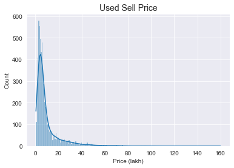

```python
nan_df = clean_df.copy() # Copy cleaned dataframe into a nan_df to process the nans

"""Remove data entries that are not useful due to missing data"""
nan_df.dropna(subset=["Price(x10^5)"], inplace=True) # Drop all rows without Price information
nan_df.dropna(subset=["Mileage(kmpl)"], inplace=True) # Drop the two Electric Vehicles from the dataset

"""Solve large amount of missing values in New_Price"""
rows, cols = nan_df.shape
nans = nan_df["New_Price(x10^5)"].isna().sum()
print(f"New Price is missing {round(nans/rows * 100)}% of the data")

sns.histplot(data=nan_df, x="Price(x10^5)", kde=True)
plt.title('Used Sell Price', fontdict={'fontsize':14})
plt.xlabel('Price (lakh)')
plt.savefig("UsedPrice.png", dpi=300, bbox_inches='tight')

# plt.show()
# sns.histplot(data=nan_df, x="Price(x10^5)", kde=True)
# plt.show()
# nan_df[["New_Price(x10^5)", "Price(x10^5)"]].describe()
```

#### Due to over 4/5ths of the data missing for this variable, I am going to simply remove it from the analysis. The median or mean with which I could draw may not be representative of the rest of the dataset. This idea is supported by the fact that the actual Price by which a used car sells has a much larger range past the maximum of the New Price.

```python
nan_df.drop("New_Price(x10^5)", axis=1, inplace=True) # Drop New Price from dataset

# Reset all categorical variables to remove categories for which there is no longer data
categorical = ['Location', 'Fuel_Type', 'Transmission', 'Owner_Type', 'Make', 'Model']
for i in categorical:
    nan_df[i] = nan_df[i].astype('object').astype('category')

print(nan_df.isna().sum())
nan_df.info()
```

```
Location               0
Year                   0
Kilometers_Driven      0
Fuel_Type              0
Transmission           0
Owner_Type             0
Mileage(kmpl)          0
Engine(CC)            36
Power(bhp)           143
Seats                 42
Price(x10^5)           0
Make                   0
Model                  0
dtype: int64
<class 'pandas.core.frame.DataFrame'>
Int64Index: 6017 entries, 0 to 6018
Data columns (total 13 columns):
 #   Column             Non-Null Count  Dtype
---  ------             --------------  -----
 0   Location           6017 non-null   category
 1   Year               6017 non-null   int64
 2   Kilometers_Driven  6017 non-null   int64
 3   Fuel_Type          6017 non-null   category
 4   Transmission       6017 non-null   category
 5   Owner_Type         6017 non-null   category
 6   Mileage(kmpl)      6017 non-null   float64
 7   Engine(CC)         5981 non-null   float64
 8   Power(bhp)         5874 non-null   float64
 9   Seats              5975 non-null   float64
 10  Price(x10^5)       6017 non-null   float64
 11  Make               6017 non-null   category
 12  Model              6017 non-null   category
dtypes: category(6), float64(5), int64(2)
memory usage: 498.6 KB
```

```python
n1 = len(nan_df["Model"].value_counts())
n2 = len(nan_df["Make"].value_counts())
print(f"There are {n1} Models and {n2} Makes in the dataset")
```

```
There are 1874 Models and 30 Makes in the dataset
```

```python
"""Group data by model to match missing values on varous metrics to the same model vehicle which has reported that value"""
model_median = nan_df.groupby('Model').median() # find median for all numerical values based on car model

models = model_median.index.to_list()

kmpl = model_median["Mileage(kmpl)"].to_list()
seats = model_median["Seats"].to_list()
power = model_median["Power(bhp)"].to_list()
engine = model_median["Engine(CC)"].to_list()

kmpl_dict = {models[i]: kmpl[i] for i in range(len(models))}
seats_dict = {models[i]: seats[i] for i in range(len(models))}
power_dict = {models[i]: power[i] for i in range(len(models))}
engine_dict = {models[i]: engine[i] for i in range(len(models))}

nan_df.replace(0, np.nan, inplace=True)

nan_df.fillna(kmpl_dict, inplace=True)
nan_df.fillna(seats_dict, inplace=True)
nan_df.fillna(power_dict, inplace=True)
nan_df.fillna(engine_dict, inplace=True)
```

```python
nan_df.isna().sum()
```

```
Location               0
Year                   0
Kilometers_Driven      0
Fuel_Type              0
Transmission           0
Owner_Type             0
Mileage(kmpl)         68
Engine(CC)            36
Power(bhp)           143
Seats                 43
Price(x10^5)           0
Make                   0
Model                  0
dtype: int64
```

#### This leaves new NaNs, which used to be 0s for Mileage and and adds one NaN to Seats

- Will need to interpolate variables in other ways

```python
nan_df["Model"].sample(12)
```

```
519                   Creta 1.6 SX
2318                 XUV500 W8 2WD
422     Polo Petrol Trendline 1.2L
3140               Amaze S i-Dtech
5174        Alto 800 2016-2019 VXI
2555               Amaze E i-Dtech
1579         Grand i10 Asta Option
4204          7 Series 730Ld Sedan
5845           5 Series 525d Sedan
770                   Cruze LTZ AT
4365                      Laura RS
5505                     Swift VDI
Name: Model, dtype: category
Categories (1874, object): ['1 Series 118d Base', '1 Series 118d Sport Line', '1000 AC', '3 Series 2005-2011 325i Sedan', ..., 'i20 Sportz Petrol', 'redi-GO S', 'redi-GO T', 'redi-GO T Option']
```

#### Notes

- Model contains not only what model, but freqently contains engine type (CC) as a decimal(float).
- It also contains seat numbers as integegers. Attempting to extract these may help fill in NaNs within Engine and Seat

That said, we can use both **Make** and **Model** to interpolate **Engine** and other variables that are specific to a type of vehicle.

```python
"""Clean Model data for useful information"""
cc = nan_df['Model'].str.extract(r"([0-9]\.[0-9])") # Use regex to pull all decimal values from models (Engine Information)
cc.value_counts() # Check that all values pulled are reasonable, no likely errorsb
```

```
1.2    514
1.5    304
1.6    287
2.0    218
1.4    171
2.5    123
1.8    102
3.0     95
1.3     64
2.4     63
1.1     57
2.8     50
2.2     43
1.0     37
1.9     31
3.2     17
2.6     10
2.7      7
4.2      7
3.6      4
4.4      2
2.3      2
5.0      2
dtype: int64
```

```python
# All values pulled by extract are resonable for the Engine CC of various vehicles
cc = cc.astype('float64').multiply(1000) # Make float and multiply so values match those order of CC reported in dataframe
new = nan_df[["Engine(CC)"]].merge(cc, how='inner', left_index=True, right_index=True) # Place Engine and CC data into dataframe for comparison

print(new[new["Engine(CC)"].isna()].shape) # There are 36 NaN values to be filled
new[new["Engine(CC)"].isna()] # Ascertain that CC data should help fill in some missing information in Engineb
```

```
(36, 2)
```

|  | Engine(CC) | 0 |
| --- | --- | --- |
| 194 | NaN | 1500.0 |
| 208 | NaN | 1300.0 |
| 733 | NaN | 1300.0 |
| 749 | NaN | 3000.0 |
| 1294 | NaN | 1300.0 |
| 1327 | NaN | 1300.0 |
| 1385 | NaN | 1500.0 |
| 1460 | NaN | NaN |
| 2074 | NaN | 1300.0 |
| 2096 | NaN | NaN |
| 2264 | NaN | NaN |
| 2325 | NaN | 1300.0 |
| 2335 | NaN | 1300.0 |
| 2530 | NaN | NaN |
| 2542 | NaN | NaN |
| 2623 | NaN | NaN |
| 2668 | NaN | 1300.0 |
| 2737 | NaN | NaN |
| 2780 | NaN | NaN |
| 2842 | NaN | NaN |
| 3272 | NaN | NaN |
| 3404 | NaN | 1300.0 |
| 3520 | NaN | NaN |
| 3522 | NaN | NaN |
| 3810 | NaN | NaN |
| 4011 | NaN | 1300.0 |
| 4152 | NaN | 3000.0 |
| 4229 | NaN | NaN |
| 4577 | NaN | NaN |
| 4604 | NaN | NaN |
| 4697 | NaN | 1200.0 |
| 4712 | NaN | NaN |
| 4952 | NaN | 1400.0 |
| 5015 | NaN | 1300.0 |
| 5185 | NaN | 1300.0 |
| 5270 | NaN | 1500.0 |

```python
cc_fills = new[new["Engine(CC)"].isna()][0].dropna().to_dict() # Create Dictionary of Index and Value to be replaced
nan_df["Engine(CC)"] = nan_df["Engine(CC)"].fillna(cc_fills) # Fill missing values
del new, cc_fills

nan_df.isna().sum() # Check progress
# Dropped missing Engine values to 17; fill the rest with median or mean value
```

```
Location               0
Year                   0
Kilometers_Driven      0
Fuel_Type              0
Transmission           0
Owner_Type             0
Mileage(kmpl)         68
Engine(CC)            17
Power(bhp)           143
Seats                 43
Price(x10^5)           0
Make                   0
Model                  0
dtype: int64
```

```python
# Repeat process to find integers for seat information
n_seats = nan_df['Model'].str.extract(r"(\s[0-9]\s)") # Extract single digits with spaces on either side
n_seats.value_counts() # Check that all values pulled are reasonable, no likely errors
```

```
 7     70
 8     52
 2     17
 5     16
 4      7
 3      6
 9      1
dtype: int64
```

```python
n_seats.astype("int", errors='ignore') # Convert digits to integers, ignore the presence of NaNs
new = nan_df[["Seats"]].merge(n_seats, how='inner', left_index=True, right_index=True) # Place Seats and n_seats data into dataframe for comparison
new[new[0].isna() == False] # Check matches, some do not match. May not be usable or need more effective extraction
```

|  | Seats | 0 |
| --- | --- | --- |
| 14 | 5.0 | 2 |
| 78 | 7.0 | 7 |
| 105 | 5.0 | 5 |
| 111 | 5.0 | 5 |
| 115 | 7.0 | 7 |
| 161 | 7.0 | 7 |
| 185 | 8.0 | 8 |
| 242 | 7.0 | 7 |
| 300 | 7.0 | 7 |
| 313 | 5.0 | 8 |
| 440 | 5.0 | 5 |
| 469 | 7.0 | 7 |
| 543 | 7.0 | 7 |
| 546 | 7.0 | 7 |
| 593 | 7.0 | 7 |
| 602 | 8.0 | 8 |
| 632 | 5.0 | 5 |
| 653 | 7.0 | 4 |
| 660 | 7.0 | 7 |
| 663 | 7.0 | 7 |
| 701 | 5.0 | 2 |
| 712 | 5.0 | 5 |
| 746 | 5.0 | 5 |
| 774 | 8.0 | 8 |
| 790 | 8.0 | 8 |
| 842 | 7.0 | 7 |
| 860 | 8.0 | 7 |
| 912 | 7.0 | 7 |
| 918 | 7.0 | 7 |
| 965 | 8.0 | 7 |

[output cut: 139 more lines]

```python
new[new['Seats'].isna()] # None of the matches help remove NaNs from Seats
# Process was flawed, but not worth continuing regardless if no NaNs will be relaced
```

|  | Seats | 0 |
| --- | --- | --- |
| 194 | NaN | NaN |
| 208 | NaN | NaN |
| 229 | NaN | NaN |
| 733 | NaN | NaN |
| 749 | NaN | NaN |
| 1294 | NaN | NaN |
| 1327 | NaN | NaN |
| 1385 | NaN | NaN |
| 1460 | NaN | NaN |
| 1917 | NaN | NaN |
| 2074 | NaN | NaN |
| 2096 | NaN | NaN |
| 2264 | NaN | NaN |
| 2325 | NaN | NaN |
| 2335 | NaN | NaN |
| 2369 | NaN | NaN |
| 2530 | NaN | NaN |
| 2542 | NaN | NaN |
| 2623 | NaN | NaN |
| 2668 | NaN | NaN |
| 2737 | NaN | NaN |
| 2780 | NaN | NaN |
| 2842 | NaN | NaN |
| 3272 | NaN | NaN |
| 3404 | NaN | NaN |
| 3520 | NaN | NaN |
| 3522 | NaN | NaN |
| 3800 | NaN | NaN |
| 3810 | NaN | NaN |
| 3882 | NaN | NaN |
| 3999 | NaN | NaN |
| 4011 | NaN | NaN |
| 4152 | NaN | NaN |
| 4229 | NaN | NaN |
| 4577 | NaN | NaN |
| 4604 | NaN | NaN |
| 4697 | NaN | NaN |
| 4712 | NaN | NaN |
| 4952 | NaN | NaN |
| 5015 | NaN | NaN |
| 5185 | NaN | NaN |
| 5270 | NaN | NaN |
| 5893 | NaN | NaN |

#### Notes

- None of the model names which give us information on the seats will fill in NaN information, so this will not help us in this case.
- It should be possible to more accurately estimate the seats in a vehicle based on the type (Racing, Sports, etc). However, as of now I am unaware of a fast way to accomplish that besides manually building a dictionary of the acronyms for those, searching the model strings, and giving an assigned number of seats based on that information. For now, **I will simply take a median or mean value for seats as it's correlation is not high relative to other features of the car.** *Building such a dictionary to make more careful seat number assignments may be a simple, but more time intesive way to improve the accuracy of the model in the future.*

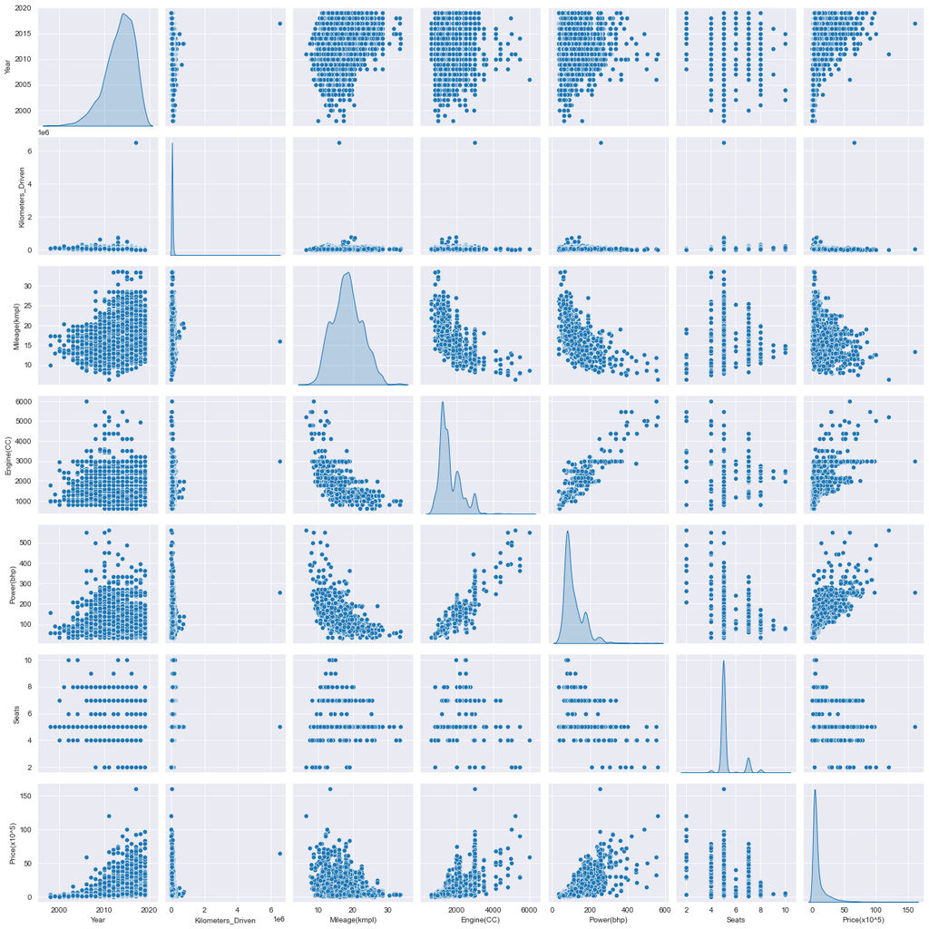

```python
"""Explore data for ways to interpolate the remaining NaNs"""
sns.pairplot(nan_df, diag_kind="kde") # Examine general trends between numerical data
```

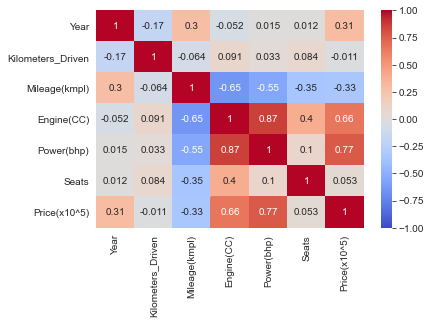

```python
sns.heatmap(nan_df.corr(), vmin=-1, vmax=1, cmap='coolwarm', annot=True) # Look at Pearson Coeff relationships
plt.savefig('CorrelationCoeff.png', dpi=300, bbox_inches='tight')
```

#### Notes

- **Year** and **Kilometers driven** have very few correlations of any stength in a positive or negative direction.
- The *strongest positive correlation* is bewteen **Engine** and **Power**.
- The *strongest negative correlation* is between **Engine** and **Mileage**.

Once **Engine** is interpolated,**Power** and **Mileage** should be interpolated from that information. Will need to categorical infomration such as **Make** and **Model** to find the Engine.

```python
sns.histplot(data=nan_df, x="Engine(CC)", kde=True) # Examine distrubtion of Engine
```

[output not shown]

```python
sns.histplot(data=nan_df, x="Engine(CC)", kde=True) # Examine distrubtion of Engine
# plt.show()
```

[output not shown]

```python
sns.histplot(data=nan_df, x="Engine(CC)", kde=True) # Examine distrubtion of Engine
# plt.show()
```

[output not shown]

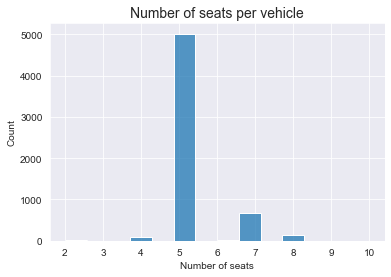

```python
sns.histplot(data=nan_df, x="Seats") # Examine distribution of Seats
plt.title('Number of seats per vehicle', fontdict={'fontsize':14})
plt.xlabel('Number of seats')
plt.savefig("SeatsDist.png", dpi=300, bbox_inches='tight')
plt.show()
```

```python
# print(nan_df[["Engine(CC)", "Seats"]].isna().sum()) # Assess number of Nans
# nan_df[["Engine(CC)", "Seats"]].describe() # Descriptive stats for both columns
```

#### Due to the small number of NaNs left in each column and that neither distribution is normally distributed, the median of Engine and Seats for all the vehicles will be used to fill the remainder.

```python
nan_df['Engine(CC)'].fillna(nan_df["Engine(CC)"].median(), inplace=True) # Replace remaining Engine NaNs with median
nan_df['Seats'].fillna(nan_df.Seats.median(), inplace=True) # Replace remaining Seats NaNs with median
nan_df.isna().sum()
```

```
Location               0
Year                   0
Kilometers_Driven      0
Fuel_Type              0
Transmission           0
Owner_Type             0
Mileage(kmpl)         68
Engine(CC)             0
Power(bhp)           143
Seats                  0
Price(x10^5)           0
Make                   0
Model                  0
dtype: int64
```

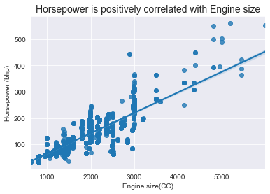

```python
"""Solve for Power(bhp) NaNs using regression info of Engine to Power.
Must remove NaNs from Power to find relationship between known datapoints"""
no_nans = nan_df.dropna(subset=['Power(bhp)']) # Create dataframe without NaNs for Power
# Plot relationship
sns.regplot(data=no_nans, x="Engine(CC)", y="Power(bhp)", scatter=True, fit_reg=True, x_ci='ci', truncate=True)
plt.title('Horsepower is positively correlated with Engine size', fontdict={'fontsize':14})
plt.xlabel('Engine size(CC)')
plt.ylabel('Horsepower (bhp)')
plt.savefig("PowervsEngine.png", dpi=300, bbox_inches='tight')
```

#### Relationship is clearly linear. Will simply find linear relationship and calculate Power based on Engine type.

```python
x = no_nans["Engine(CC)"]
y = no_nans["Power(bhp)"]

m, y_int, r, p, ste = stats.linregress(x, y) # Find slope and y-intercept for relationship
print(m, y_int)
nans = nan_df[nan_df["Power(bhp)"].isna()] # Select nans from Power
x = nans["Engine(CC)"] # Find subset of Engine data that correspond to the nans
y = x.multiply(m).add(y_int) # Make linear interpolation

nan_df["Power(bhp)"].fillna(y.to_dict(), inplace=True) # Replace the NaNs
nan_df.isna().sum() # Check Progress
```

```
0.07758469812304981 -12.857335909194788
```

```
Location              0
Year                  0
Kilometers_Driven     0
Fuel_Type             0
Transmission          0
Owner_Type            0
Mileage(kmpl)        68
Engine(CC)            0
Power(bhp)            0
Seats                 0
Price(x10^5)          0
Make                  0
Model                 0
dtype: int64
```

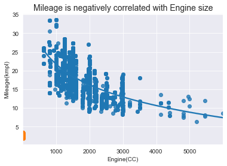

```python
"""Solve for Mileage(kmpl) NaNs using regression info of Engine to Mileage.
Must remove NaNs from Power to find relationship between known datapoints"""
no_nans = nan_df.dropna(subset=['Mileage(kmpl)']) # Create dataframe without NaNs for Power
# Plot relationship
sns.regplot(data=no_nans, x="Engine(CC)", y="Mileage(kmpl)", scatter=True, fit_reg=True, x_ci='ci', truncate=True,
           logx=True)
plt.title('Mileage is negatively correlated with Engine size', fontdict={'fontsize':14})
# plt.xlabel('Engine size(CC)')
# plt.ylabel('Mileage (kmpl)')
# plt.savefig("MileagevsEngine.png", dpi=300, bbox_inches='tight')
# plt.show()

#Log transformation
log_trans= pd.DataFrame()
for i in ["Engine(CC)", "Mileage(kmpl)"]:
    log_trans[i] = np.log(no_nans[i])

sns.regplot(data=log_trans, x="Engine(CC)", y="Mileage(kmpl)", scatter=True, fit_reg=True, x_ci='ci', truncate=True)
```

#### Relationship is most likely log(x) as opposed to linear. Will do a log transformation, find linear relationship, interpolate, than return to values through the inverse, e^x.

```python
x = np.log(no_nans["Engine(CC)"])
y = np.log(no_nans["Mileage(kmpl)"])

m, y_int, r, p, ste = stats.linregress(x, y) # Find slope and y-intercept for relationship
print(m, y_int)
nans = nan_df[nan_df["Mileage(kmpl)"].isna()] # Select nans from Power
x = np.log(nans["Engine(CC)"]) # Find subset of Engine data that correspond to the nans
y = x.multiply(m).add(y_int) # Make linear interpolation
y = np.exp(y) # Undo transformation to return values to normal range

nan_df["Mileage(kmpl)"].fillna(y.to_dict(), inplace=True) # Replace the NaNs
nan_df.isna().sum() # Check Progress
```

```
-0.4748615226784998 6.363283822413574
```

```
Location             0
Year                 0
Kilometers_Driven    0
Fuel_Type            0
Transmission         0
Owner_Type           0
Mileage(kmpl)        0
Engine(CC)           0
Power(bhp)           0
Seats                0
Price(x10^5)         0
Make                 0
Model                0
dtype: int64
```

## Generation of Linear Model

```python
df = nan_df.copy() # copy completely cleaned dataframe
df.drop('Model', axis=1, inplace=True) # Too many categories for model (1084), removed

del nan_df, clean_df # delete dfs from cleaning
df.describe(include='all')
```

|  | Location | Year | Kilometers_Driven | Fuel_Type | Transmission | Owner_Type | Mileage(kmpl) | Engine(CC) | Power(bhp) | Seats | Price(x10^5) | Make |
| --- | --- | --- | --- | --- | --- | --- | --- | --- | --- | --- | --- | --- |
| count | 6017 | 6017.000000 | 6.017000e+03 | 6017 | 6017 | 6017 | 6017.000000 | 6017.000000 | 6017.000000 | 6017.000000 | 6017.000000 | 6017 |
| unique | 11 | NaN | NaN | 4 | 2 | 4 | NaN | NaN | NaN | NaN | NaN | 30 |
| top | Mumbai | NaN | NaN | Diesel | Manual | First | NaN | NaN | NaN | NaN | NaN | Maruti |
| freq | 789 | NaN | NaN | 3205 | 4299 | 4927 | NaN | NaN | NaN | NaN | NaN | 1211 |
| mean | NaN | 2013.358152 | 5.874228e+04 | NaN | NaN | NaN | 18.335845 | 1620.792421 | 112.891355 | 5.277713 | 9.478340 | NaN |
| std | NaN | 3.269967 | 9.128375e+04 | NaN | NaN | NaN | 4.168151 | 600.091023 | 53.615389 | 0.803597 | 11.189605 | NaN |
| min | NaN | 1998.000000 | 1.710000e+02 | NaN | NaN | NaN | 6.400000 | 624.000000 | 34.200000 | 2.000000 | 0.440000 | NaN |
| 25% | NaN | 2011.000000 | 3.400000e+04 | NaN | NaN | NaN | 15.300000 | 1198.000000 | 75.000000 | 5.000000 | 3.500000 | NaN |
| 50% | NaN | 2014.000000 | 5.300000e+04 | NaN | NaN | NaN | 18.200000 | 1493.000000 | 94.000000 | 5.000000 | 5.640000 | NaN |
| 75% | NaN | 2016.000000 | 7.300000e+04 | NaN | NaN | NaN | 21.100000 | 1984.000000 | 138.100000 | 5.000000 | 9.950000 | NaN |
| max | NaN | 2019.000000 | 6.500000e+06 | NaN | NaN | NaN | 33.540000 | 5998.000000 | 560.000000 | 10.000000 | 160.000000 | NaN |

```python
# One-Hot Encode all categorical variables
categorical = ['Location', 'Fuel_Type', 'Transmission', 'Owner_Type', 'Make']
for i in categorical:
    one_hot = pd.get_dummies(df[i], prefix=i)
    df = pd.concat([df, one_hot], axis=1)
    df.drop(i, axis=1, inplace=True)
```

### Build basic model

```python
X = df.drop('Price(x10^5)', axis=1)
Y = df['Price(x10^5)']

X_train, X_test, Y_train, Y_test = train_test_split(
    X, Y, test_size=0.30, random_state=42)

regression_model = LinearRegression()
regression_model.fit(X_train, Y_train)

print(f'The score for the training dataset is {regression_model.score(X_train, Y_train)}')
print(f'The score for the testing dataset is {regression_model.score(X_test, Y_test)}')
```

```
The score for the training dataset is 0.7791287850386813
The score for the testing dataset is 0.7641199637068729
```

### Check for Covariance in variables

```python
from statsmodels.stats.outliers_influence import variance_inflation_factor

vif_s = pd.Series(
    [variance_inflation_factor(X.values, i)
    for i in range (X.shape[1])], index=X.columns
)

vif_s.head(6)
```

```
Year                  1.707089
Kilometers_Driven     1.072704
Mileage(kmpl)         3.836980
Engine(CC)           11.382488
Power(bhp)            9.966577
Seats                 2.559518
dtype: float64
```

#### Notes

- All One-Hot Encoded categoricals have infinte VIF ratings.
- Only these 6 (Numerical Values) have relevant VIF measures.
- Of those Engine and Power have the highest. As Engine is the highest and is likely determining of Power (I also interpolated it that way during processing) we will drop Engine and run the model again.

### Model with Colinearity accounted for

```python
X = df.drop(['Price(x10^5)', 'Engine(CC)'], axis=1)
Y = df['Price(x10^5)']

X_train, X_test, Y_train, Y_test = train_test_split(
    X, Y, test_size=0.30, random_state=42)

regression_model = LinearRegression()
regression_model.fit(X_train, Y_train)

print(f'The score for the training dataset is {regression_model.score(X_train, Y_train)}')
print(f'The score for the testing dataset is {regression_model.score(X_test, Y_test)}')
```

```
The score for the training dataset is 0.7782390082810607
The score for the testing dataset is 0.7634726787659352
```

```python
vif_s = pd.Series(
    [variance_inflation_factor(X.values, i)
    for i in range (X.shape[1])], index=X.columns
)

vif_s.head(6)
```

```
Year                  1.693284
Kilometers_Driven     1.072034
Mileage(kmpl)         3.437417
Power(bhp)            4.164029
Seats                 2.404763
Location_Ahmedabad         inf
dtype: float64
```

#### Notes

- No significant change in the model
- VIF values for remaining numerical values very good
- Need to examine p-values using statsmodels

### Model in Stat models for more detail

```python
olsmod = sm.OLS(Y_train, X_train)
olsres = olsmod.fit()
print(olsres.summary())
print('\n', f'The mean of the residuals for this model is {np.mean(olsres.resid)}')
```

```
                            OLS Regression Results
==============================================================================
Dep. Variable:           Price(x10^5)   R-squared:                       0.778
Model:                            OLS   Adj. R-squared:                  0.776
Method:                 Least Squares   F-statistic:                     298.0
Date:                Fri, 09 Jul 2021   Prob (F-statistic):               0.00
Time:                        21:48:04   Log-Likelihood:                -13013.
No. Observations:                4211   AIC:                         2.613e+04
Df Residuals:                    4161   BIC:                         2.644e+04
Df Model:                          49
Covariance Type:            nonrobust
=============================================================================================
                                coef    std err          t      P>|t|      [0.025      0.975]
---------------------------------------------------------------------------------------------
Year                          0.9964      0.033     30.267      0.000       0.932       1.061
Kilometers_Driven          2.495e-06   7.98e-07      3.128      0.002    9.31e-07    4.06e-06
Mileage(kmpl)                -0.1262      0.037     -3.394      0.001      -0.199      -0.053
Power(bhp)                    0.1001      0.003     31.312      0.000       0.094       0.106
Seats                         0.4127      0.160      2.572      0.010       0.098       0.727
Location_Ahmedabad         -161.8908      5.316    -30.456      0.000    -172.312    -151.469
Location_Bangalore         -160.0978      5.316    -30.114      0.000    -170.521    -149.675
Location_Chennai           -161.0928      5.291    -30.444      0.000    -171.467    -150.719
Location_Coimbatore        -160.0992      5.369    -29.822      0.000    -170.624    -149.574
Location_Delhi             -162.8169      5.314    -30.640      0.000    -173.235    -152.399
Location_Hyderabad         -160.4069      5.285    -30.350      0.000    -170.769    -150.045
Location_Jaipur            -161.4107      5.305    -30.426      0.000    -171.811    -151.010
Location_Kochi             -162.2000      5.368    -30.217      0.000    -172.724    -151.676
Location_Kolkata           -163.0303      5.294    -30.795      0.000    -173.409    -152.651
Location_Mumbai            -162.8069      5.318    -30.613      0.000    -173.233    -152.381
Location_Pune              -161.7438      5.300    -30.516      0.000    -172.135    -151.353
Fuel_Type_Cng              -444.0714     14.601    -30.414      0.000    -472.697    -415.446
Fuel_Type_Diesel           -444.6373     14.616    -30.421      0.000    -473.292    -415.982
Fuel_Type_Lpg              -443.3600     14.649    -30.265      0.000    -472.081    -414.639
Fuel_Type_Petrol           -445.5273     14.633    -30.446      0.000    -474.216    -416.838
Transmission_Automatic     -888.8180     29.220    -30.418      0.000    -946.105    -831.531
Transmission_Manual        -888.7780     29.175    -30.464      0.000    -945.976    -831.580
Owner_Type_First           -444.1963     14.702    -30.213      0.000    -473.020    -415.373
Owner_Type_Fourth & Above  -444.7630     14.646    -30.368      0.000    -473.476    -416.050
Owner_Type_Second          -444.7938     14.636    -30.389      0.000    -473.489    -416.099
Owner_Type_Third           -443.8428     14.568    -30.467      0.000    -472.404    -415.281
```

[output cut: 28 more lines]

```
Make_Volkswagen             -70.6853      2.175    -32.493      0.000     -74.950     -66.420
Make_Volvo                  -67.5763      2.471    -27.352      0.000     -72.420     -62.733
==============================================================================
Omnibus:                     3881.920   Durbin-Watson:                   2.016
Prob(Omnibus):                  0.000   Jarque-Bera (JB):           575218.688
Skew:                           3.892   Prob(JB):                         0.00
Kurtosis:                      59.726   Cond. No.                     1.15e+16
==============================================================================

Notes:
[1] Standard Errors assume that the covariance matrix of the errors is correctly specified.
[2] The smallest eigenvalue is 4.75e-19. This might indicate that there are
strong multicollinearity problems or that the design matrix is singular.

 The mean of the residuals for this model is 8.450919586276148e-13
```

### Normality and Linearity Tests

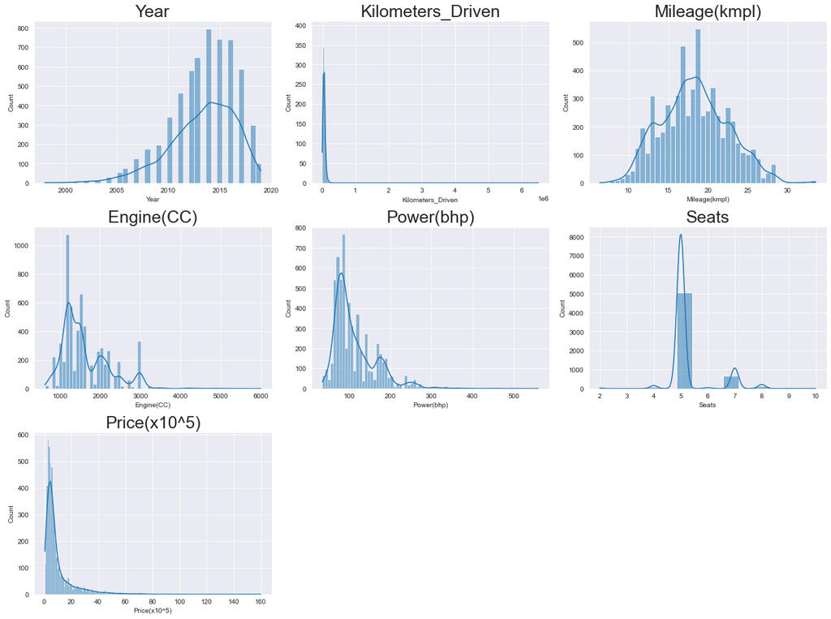

```python
all_col = df.columns.tolist()
all_col = all_col[:7]
plt.figure(figsize=(17, 75))

for i in range(len(all_col)):
    plt.subplot(18, 3, i + 1)
    sns.histplot(df[all_col[i]], kde=True)  # you can comment the previous line and run this one to get distribution curves
    plt.tight_layout()
    plt.title(all_col[i], fontsize=25)

plt.show()
```

#### Distributions certainly don't have normal appearances, will validate based on examination of the residuals

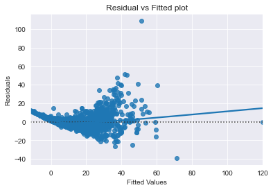

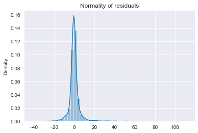

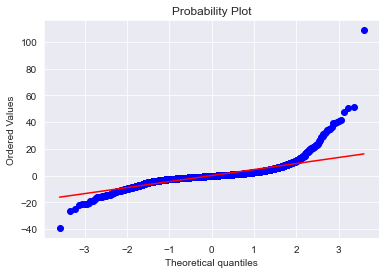

```python
rs = olsres.resid
fit = olsres.fittedvalues

sns.set_style("darkgrid")
sns.residplot(fit, rs, lowess=True)
plt.xlabel("Fitted Values")
plt.ylabel("Residuals")
plt.title("Residual vs Fitted plot")
plt.savefig("LM1_ResFittedPlot.png", dpi=300, bbox_inches='tight')
plt.show()

sns.distplot(rs)
plt.title("Normality of residuals")
plt.savefig("LM1_ResNorm.png", dpi=300, bbox_inches='tight')
plt.show()

stats.probplot(rs, dist="norm", plot=pylab)
plt.show()
```

#### Notes

- **Data is not *homoskedastic***
- **Data is not *normally distributed***
- Will need to transformations

  ### Transformations of data

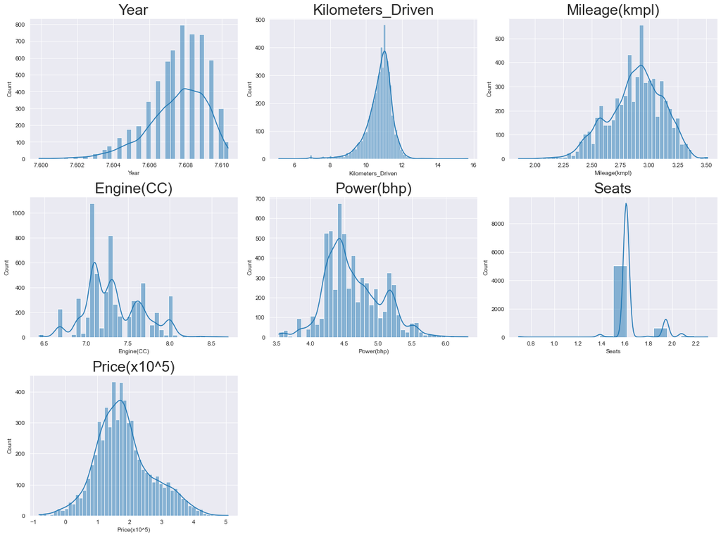

```python
"""Log transformation"""
all_col = df.columns.tolist()
all_col = all_col[:7]
plt.figure(figsize=(17, 75))

for i in range(len(all_col)):
    plt.subplot(18, 3, i + 1)
    sns.histplot(np.log(df[all_col[i]]), kde=True)  # you can comment the previous line and run this one to get distribution curves
    plt.tight_layout()
    plt.title(all_col[i], fontsize=25)

plt.show()
```

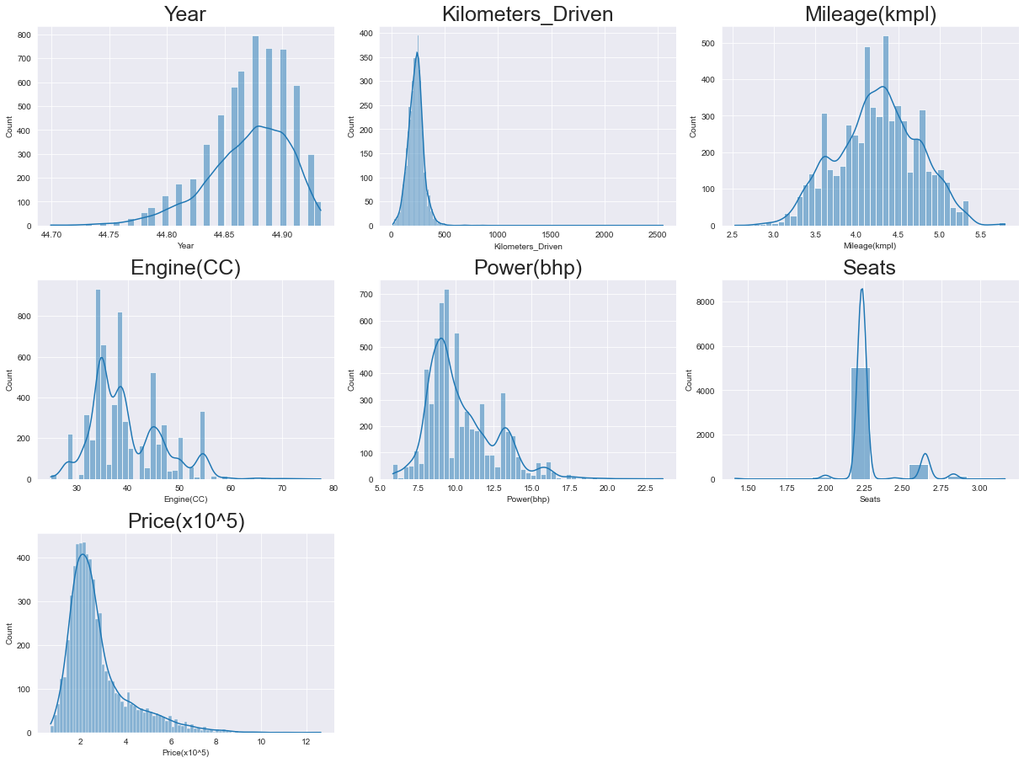

```python
all_col = df.columns.tolist()
all_col = all_col[:7]
plt.figure(figsize=(17, 75))

for i in range(len(all_col)):
    plt.subplot(18, 3, i + 1)
    sns.histplot(np.sqrt(df[all_col[i]]), kde=True)  # you can comment the previous line and run this one to get distribution curves
    plt.tight_layout()
    plt.title(all_col[i], fontsize=25)

plt.show()
```

#### Notes

- Both Kilometer_Driven and Power are significantly assisted by the a log transformation.
- Both are also assisted by a sqrt, but not to the same degree, will proceed with a log transoformation for the model.
- In particular the target, Price, gets much closer to normality with a log transformation.

### Model with Log transformation on all numerical data

```python
"""Log Transformation"""
df.iloc[:,:7] = np.log(df.iloc[:,:7])
```

```python
X = df.drop(['Price(x10^5)'], axis=1)
Y = df['Price(x10^5)']

X_train, X_test, Y_train, Y_test = train_test_split(
    X, Y, test_size=0.30, random_state=42)

olsmod = sm.OLS(Y_train, X_train)
olsres = olsmod.fit()
print(olsres.summary())
print('\n', f'The mean of the residuals for this model is {np.mean(olsres.resid)}')
```

```
                            OLS Regression Results
==============================================================================
Dep. Variable:           Price(x10^5)   R-squared:                       0.938
Model:                            OLS   Adj. R-squared:                  0.938
Method:                 Least Squares   F-statistic:                     1270.
Date:                Fri, 09 Jul 2021   Prob (F-statistic):               0.00
Time:                        22:03:05   Log-Likelihood:                 497.10
No. Observations:                4211   AIC:                            -892.2
Df Residuals:                    4160   BIC:                            -568.6
Df Model:                          50
Covariance Type:            nonrobust
=============================================================================================
                                coef    std err          t      P>|t|      [0.025      0.975]
---------------------------------------------------------------------------------------------
Year                        228.9417      3.065     74.702      0.000     222.933     234.950
Kilometers_Driven            -0.0733      0.006    -11.520      0.000      -0.086      -0.061
Mileage(kmpl)                -0.1605      0.030     -5.329      0.000      -0.220      -0.101
Engine(CC)                    0.3140      0.037      8.469      0.000       0.241       0.387
Power(bhp)                    0.7480      0.025     29.429      0.000       0.698       0.798
Seats                         0.2528      0.037      6.811      0.000       0.180       0.326
Location_Ahmedabad         -140.7708      1.881    -74.854      0.000    -144.458    -137.084
Location_Bangalore         -140.6202      1.881    -74.770      0.000    -144.307    -136.933
Location_Chennai           -140.7423      1.880    -74.857      0.000    -144.428    -137.056
Location_Coimbatore        -140.6564      1.883    -74.695      0.000    -144.348    -136.965
Location_Delhi             -140.8596      1.881    -74.889      0.000    -144.547    -137.172
Location_Hyderabad         -140.6539      1.880    -74.810      0.000    -144.340    -136.968
Location_Jaipur            -140.8065      1.881    -74.860      0.000    -144.494    -137.119
Location_Kochi             -140.8054      1.883    -74.778      0.000    -144.497    -137.114
Location_Kolkata           -141.0110      1.879    -75.038      0.000    -144.695    -137.327
Location_Mumbai            -140.8378      1.880    -74.908      0.000    -144.524    -137.152
Location_Pune              -140.8209      1.881    -74.883      0.000    -144.508    -137.134
Fuel_Type_Cng              -387.1363      5.173    -74.840      0.000    -397.278    -376.995
Fuel_Type_Diesel           -387.0319      5.173    -74.817      0.000    -397.174    -376.890
Fuel_Type_Lpg              -387.1903      5.172    -74.870      0.000    -397.329    -377.051
Fuel_Type_Petrol           -387.2264      5.172    -74.868      0.000    -397.367    -377.086
Transmission_Automatic     -774.2440     10.345    -74.841      0.000    -794.526    -753.962
Transmission_Manual        -774.3409     10.344    -74.860      0.000    -794.620    -754.061
Owner_Type_First           -387.0717      5.176    -74.785      0.000    -397.219    -376.924
Owner_Type_Fourth & Above  -387.1711      5.170    -74.894      0.000    -397.306    -377.036
Owner_Type_Second          -387.1425      5.174    -74.832      0.000    -397.285    -377.000
```

[output cut: 29 more lines]

```
Make_Volkswagen             -55.6159      0.740    -75.151      0.000     -57.067     -54.165
Make_Volvo                  -55.1691      0.740    -74.523      0.000     -56.620     -53.718
==============================================================================
Omnibus:                      383.573   Durbin-Watson:                   2.015
Prob(Omnibus):                  0.000   Jarque-Bera (JB):             2417.760
Skew:                          -0.161   Prob(JB):                         0.00
Kurtosis:                       6.698   Cond. No.                     1.13e+16
==============================================================================

Notes:
[1] Standard Errors assume that the covariance matrix of the errors is correctly specified.
[2] The smallest eigenvalue is 8.59e-27. This might indicate that there are
strong multicollinearity problems or that the design matrix is singular.

 The mean of the residuals for this model is 3.332805996140773e-12
```

```python
regression_model = LinearRegression()
regression_model.fit(X_train, Y_train)

print(f'The score for the training dataset is {regression_model.score(X_train, Y_train)}')
print(f'The score for the testing dataset is {regression_model.score(X_test, Y_test)}')
```

```
The score for the training dataset is 0.9384691702396827
The score for the testing dataset is -1.7299875826667864e+19
```

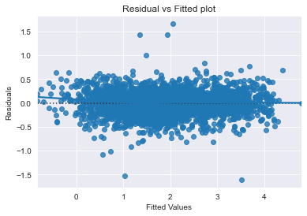

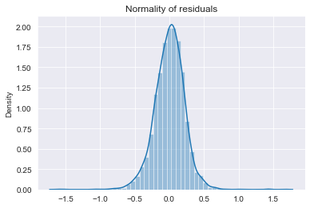

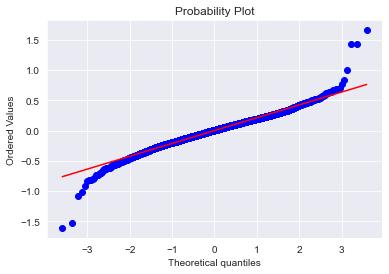

```python
rs = olsres.resid
fit = olsres.fittedvalues

sns.set_style("darkgrid")
sns.residplot(fit, rs, lowess=True)
plt.xlabel("Fitted Values")
plt.ylabel("Residuals")
plt.title("Residual vs Fitted plot")
plt.savefig("LM2_ResFittedPlot.png", dpi=300, bbox_inches='tight')
plt.show()

sns.distplot(rs)
plt.title("Normality of residuals")
plt.savefig("LM2_ResNorm.png", dpi=300, bbox_inches='tight')
plt.show()

stats.probplot(rs, dist="norm", plot=pylab)
plt.show()
```

```python
X = df.drop(['Price(x10^5)', "Engine(CC)"], axis=1)
Y = df['Price(x10^5)']

X_train, X_test, Y_train, Y_test = train_test_split(
    X, Y, test_size=0.30, random_state=42)

olsmod = sm.OLS(Y_train, X_train)
olsres = olsmod.fit()
print(olsres.summary())
print('\n', f'The mean of the residuals for this model is {np.mean(olsres.resid)}')
```

```
                            OLS Regression Results
==============================================================================
Dep. Variable:           Price(x10^5)   R-squared:                       0.937
Model:                            OLS   Adj. R-squared:                  0.937
Method:                 Least Squares   F-statistic:                     1272.
Date:                Fri, 09 Jul 2021   Prob (F-statistic):               0.00
Time:                        22:00:16   Log-Likelihood:                 461.11
No. Observations:                4211   AIC:                            -822.2
Df Residuals:                    4161   BIC:                            -504.9
Df Model:                          49
Covariance Type:            nonrobust
=============================================================================================
                                coef    std err          t      P>|t|      [0.025      0.975]
---------------------------------------------------------------------------------------------
Year                        227.2743      3.084     73.688      0.000     221.227     233.321
Kilometers_Driven            -0.0732      0.006    -11.405      0.000      -0.086      -0.061
Mileage(kmpl)                -0.2740      0.027    -10.074      0.000      -0.327      -0.221
Power(bhp)                    0.9081      0.017     53.017      0.000       0.875       0.942
Seats                         0.2991      0.037      8.078      0.000       0.226       0.372
Location_Ahmedabad         -139.6014      1.891    -73.809      0.000    -143.310    -135.893
Location_Bangalore         -139.4510      1.891    -73.725      0.000    -143.159    -135.743
Location_Chennai           -139.5723      1.891    -73.811      0.000    -143.280    -135.865
Location_Coimbatore        -139.4857      1.894    -73.650      0.000    -143.199    -135.773
Location_Delhi             -139.6911      1.892    -73.843      0.000    -143.400    -135.982
Location_Hyderabad         -139.4844      1.891    -73.765      0.000    -143.192    -135.777
Location_Jaipur            -139.6368      1.892    -73.815      0.000    -143.346    -135.928
Location_Kochi             -139.6365      1.894    -73.733      0.000    -143.349    -135.924
Location_Kolkata           -139.8419      1.890    -73.991      0.000    -143.547    -136.137
Location_Mumbai            -139.6670      1.891    -73.862      0.000    -143.374    -135.960
Location_Pune              -139.6501      1.891    -73.837      0.000    -143.358    -135.942
Fuel_Type_Cng              -383.9010      5.202    -73.794      0.000    -394.100    -373.702
Fuel_Type_Diesel           -383.7873      5.202    -73.770      0.000    -393.987    -373.588
Fuel_Type_Lpg              -383.9947      5.201    -73.826      0.000    -394.192    -373.797
Fuel_Type_Petrol           -384.0352      5.202    -73.824      0.000    -394.234    -373.836
Transmission_Automatic     -767.8127     10.405    -73.796      0.000    -788.211    -747.414
Transmission_Manual        -767.9056     10.403    -73.814      0.000    -788.302    -747.510
Owner_Type_First           -383.8494      5.205    -73.740      0.000    -394.055    -373.644
Owner_Type_Fourth & Above  -383.9738      5.199    -73.849      0.000    -394.168    -373.780
Owner_Type_Second          -383.9197      5.203    -73.786      0.000    -394.121    -373.719
Owner_Type_Third           -383.9754      5.200    -73.835      0.000    -394.171    -373.780
```

[output cut: 28 more lines]

```
Make_Volkswagen             -55.1690      0.744    -74.110      0.000     -56.628     -53.710
Make_Volvo                  -54.7591      0.745    -73.506      0.000     -56.220     -53.299
==============================================================================
Omnibus:                      366.026   Durbin-Watson:                   2.022
Prob(Omnibus):                  0.000   Jarque-Bera (JB):             2314.424
Skew:                          -0.098   Prob(JB):                         0.00
Kurtosis:                       6.627   Cond. No.                     1.18e+16
==============================================================================

Notes:
[1] Standard Errors assume that the covariance matrix of the errors is correctly specified.
[2] The smallest eigenvalue is 6.33e-27. This might indicate that there are
strong multicollinearity problems or that the design matrix is singular.

 The mean of the residuals for this model is 4.4943060856314146e-12
```

```python
regression_model = LinearRegression()
regression_model.fit(X_train, Y_train)

print(f'The score for the training dataset is {regression_model.score(X_train, Y_train)}')
print(f'The score for the testing dataset is {regression_model.score(X_test, Y_test)}')
```

```
The score for the training dataset is 0.9374383324900343
The score for the testing dataset is -2.5793345257476563e+17
```

### The test dataset fails. This likely due to overfitting of the model now that the data has been normalized.

### Remove all categorical for a simpler 5 variable model to prevent overfitting

```python
"""Remove all categorical One-Hot Encodes to focus on just the numerical data"""
X = df.iloc[:,:7]
X = X.drop(['Price(x10^5)', 'Engine(CC)'], axis=1)
Y = df['Price(x10^5)']

X_train, X_test, Y_train, Y_test = train_test_split(
    X, Y, test_size=0.30, random_state=42)

olsmod = sm.OLS(Y_train, X_train)
olsres = olsmod.fit()
print(olsres.summary())
print('\n', f'The mean of the residuals for this model is {np.mean(olsres.resid)}')
```

```
                                 OLS Regression Results
=======================================================================================
Dep. Variable:           Price(x10^5)   R-squared (uncentered):                   0.947
Model:                            OLS   Adj. R-squared (uncentered):              0.947
Method:                 Least Squares   F-statistic:                          1.503e+04
Date:                Fri, 09 Jul 2021   Prob (F-statistic):                        0.00
Time:                        22:10:20   Log-Likelihood:                         -2753.2
No. Observations:                4211   AIC:                                      5516.
Df Residuals:                    4206   BIC:                                      5548.
Df Model:                           5
Covariance Type:            nonrobust
=====================================================================================
                        coef    std err          t      P>|t|      [0.025      0.975]
-------------------------------------------------------------------------------------
Year                 -0.9711      0.034    -28.891      0.000      -1.037      -0.905
Kilometers_Driven    -0.3010      0.011    -28.615      0.000      -0.322      -0.280
Mileage(kmpl)         0.7876      0.040     19.533      0.000       0.709       0.867
Power(bhp)            1.9053      0.022     87.445      0.000       1.863       1.948
Seats                 0.8230      0.056     14.720      0.000       0.713       0.933
==============================================================================
Omnibus:                      133.473   Durbin-Watson:                   2.023
Prob(Omnibus):                  0.000   Jarque-Bera (JB):              212.148
Skew:                          -0.295   Prob(JB):                     8.56e-47
Kurtosis:                       3.928   Cond. No.                         127.
==============================================================================

Notes:
[1] R² is computed without centering (uncentered) since the model does not contain a constant.
[2] Standard Errors assume that the covariance matrix of the errors is correctly specified.

 The mean of the residuals for this model is -5.038767392215665e-05
```

```python
X = df.iloc[:,:7]
X = X.drop(['Price(x10^5)', 'Engine(CC)'], axis=1)
Y = df['Price(x10^5)']

X_train, X_test, Y_train, Y_test = train_test_split(
    X, Y, test_size=0.30, random_state=42)

regression_model = LinearRegression()
regression_model.fit(X_train, Y_train)

print(f'The score for the training dataset is {regression_model.score(X_train, Y_train)}')
print(f'The score for the testing dataset is {regression_model.score(X_test, Y_test)}')
```

```
The score for the training dataset is 0.8369212593882065
The score for the testing dataset is 0.8286889188341457
```

### I believe this last model to be the best. This is because:

- The has the same, and a high R-squared and Adjusted R-Squared Value (0.947)
- The model has similar values for the training and test score, 0.84 and 0.83 correspondingly
- The meand of the residudual is approximately 0
- This is a fairly conservative model, yet it yeilds strong results
- The coefficients are easy to interpret with regards to how the different variable effect the outcome